# Practical Machine Learning Project

AJ Hess

Thursday, January 22, 2015

#### Background Information

Using devices such as Jawbone Up, Nike FuelBand, and Fitbit it is now possible to collect a large amount of data about personal activity relatively inexpensively. These type of devices are part of the quantified self movement - a group of enthusiasts who take measurements about themselves regularly to improve their health, to find patterns in their behavior, or because they are tech geeks. One thing that people regularly do is quantify how much of a particular activity they do, but they rarely quantify how well they do it. In this project, your goal will be to use data from accelerometers on the belt, forearm, arm, and dumbell of 6 participants. They were asked to perform barbell lifts correctly and incorrectly in 5 different ways. More information is available from the website here: [http://groupware.les.inf.puc-rio.br/har] (see the section on the Weight Lifting Exercise Dataset).

#### Data Sources

*The training data for this project are available here*:  
[https://d396qusza40orc.cloudfront.net/predmachlearn/pml-training.csv]

*The test data are available here*:  
[https://d396qusza40orc.cloudfront.net/predmachlearn/pml-testing.csv]

The data for this project come from this source: [http://groupware.les.inf.puc-rio.br/har]. If you use the document you create for this class for any purpose please cite them as they have been very generous in allowing their data to be used for this kind of assignment.

#### Data Preparation

Below we’ll load necessary libraries to perform the analysis, load the data and clean up the data by removing any missing values.

```r
#load needed libraries
library(caret)
library(rpart)
library(rpart.plot)
library(RColorBrewer)
library(rattle)
library(randomForest)
library(e1071)

#set seed
set.seed(140819)

# Read in the training and testing data

testUrl <- "http://d396qusza40orc.cloudfront.net/predmachlearn/pml-testing.csv"
trainUrl <- "http://d396qusza40orc.cloudfront.net/predmachlearn/pml-training.csv"
training <- read.csv(url(trainUrl), na.strings=c("NA","#DIV/0!",""))
testing <- read.csv(url(testUrl), na.strings=c("NA","#DIV/0!",""))

#create testing and training set
inTrain <- createDataPartition(y=training$classe, p=0.6, list=FALSE)
myTraining <- training[inTrain, ]; myTesting <- training[-inTrain, ]
dim(myTraining); dim(myTesting)
```

```
## [1] 11776   160
```

```
## [1] 7846  160
```

```r
# Function to filter the features

##remove features with any missing data
filterData <- function(idf) {
# Since we have lots of variables, remove any with NA's or have empty strings
  idx.keep <- !sapply(idf, function(x) any(is.na(x)))
  idf <- idf[, idx.keep]
  idx.keep <- !sapply(idf, function(x) any(x==""))
  idf <- idf[, idx.keep]

#Remove the columns that aren't the predictor variables
  col.rm <- c("X", "user_name", "raw_timestamp_part_1", "raw_timestamp_part_2",
              "cvtd_timestamp", "new_window", "num_window")
  idx.rm <- which(colnames(idf) %in% col.rm)
  idf <- idf[, -idx.rm]

  return(idf)
}

# Perform the filtering on the datasets
myTraining <- filterData(myTraining)
myTraining$classe <- factor(myTraining$classe)
myTesting <- filterData(myTesting)

dim(myTraining); dim(myTesting)
```

```
## [1] 11776    53
```

```
## [1] 7846   53
```

#### Creating the Model - Decision Tree

Now we build a model and view the output using the Decision Tree algorithm

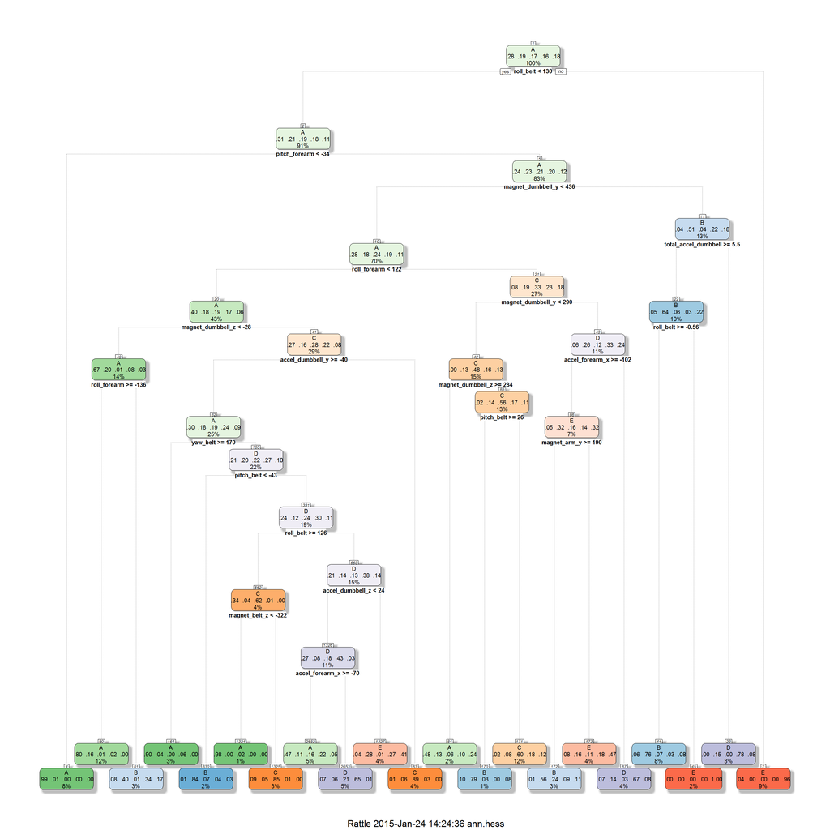

```r
#now create the model
modFitA1 <- rpart(classe ~ ., data=myTraining, method="class")
#and view the decision tree
fancyRpartPlot(modFitA1)
```

Now we want to try predicting using the test dataset we created earlier, and use a confusion matrix to test the results

```r
#try prediction with testing dataset
predictionsA1 <- predict(modFitA1, myTesting, type = "class")

#create confusion matrix to test the results
confusionMatrix(predictionsA1, myTesting$classe)
```

```
## Confusion Matrix and Statistics
##
##           Reference
## Prediction    A    B    C    D    E
##          A 2003  277   88  150   61
##          B   81  873  109  102  111
##          C   39   96 1036  171  139
##          D   42  119   95  718   57
##          E   67  153   40  145 1074
##
## Overall Statistics
##
##                Accuracy : 0.727
##                  95% CI : (0.717, 0.737)
##     No Information Rate : 0.284
##     P-Value [Acc > NIR] : <2e-16
##
##                   Kappa : 0.653
##  Mcnemar's Test P-Value : <2e-16
##
## Statistics by Class:
##
##                      Class: A Class: B Class: C Class: D Class: E
## Sensitivity             0.897    0.575    0.757   0.5583    0.745
## Specificity             0.897    0.936    0.931   0.9523    0.937
## Pos Pred Value          0.777    0.684    0.700   0.6964    0.726
## Neg Pred Value          0.957    0.902    0.948   0.9167    0.942
## Prevalence              0.284    0.193    0.174   0.1639    0.184
## Detection Rate          0.255    0.111    0.132   0.0915    0.137
## Detection Prevalence    0.329    0.163    0.189   0.1314    0.189
## Balanced Accuracy       0.897    0.756    0.844   0.7553    0.841
```

#### Creating the Model - Random Forest

Now we build a model and view the output using the Random Forest algorithm

```r
#create the model
modFitB1 <- randomForest(classe ~. , data=myTraining)

#try prediction with testing dataset
predictionsB1 <- predict(modFitB1, myTesting, type = "class")

#create the confusion matrix to test the results
confusionMatrix(predictionsB1, myTesting$classe)
```

```
## Confusion Matrix and Statistics
##
##           Reference
## Prediction    A    B    C    D    E
##          A 2231   17    0    0    0
##          B    0 1497    3    0    0
##          C    1    4 1365   14    0
##          D    0    0    0 1269    4
##          E    0    0    0    3 1438
##
## Overall Statistics
##
##                Accuracy : 0.994
##                  95% CI : (0.992, 0.996)
##     No Information Rate : 0.284
##     P-Value [Acc > NIR] : <2e-16
##
##                   Kappa : 0.993
##  Mcnemar's Test P-Value : NA
##
## Statistics by Class:
##
##                      Class: A Class: B Class: C Class: D Class: E
## Sensitivity             1.000    0.986    0.998    0.987    0.997
## Specificity             0.997    1.000    0.997    0.999    1.000
## Pos Pred Value          0.992    0.998    0.986    0.997    0.998
## Neg Pred Value          1.000    0.997    1.000    0.997    0.999
## Prevalence              0.284    0.193    0.174    0.164    0.184
## Detection Rate          0.284    0.191    0.174    0.162    0.183
## Detection Prevalence    0.287    0.191    0.176    0.162    0.184
## Balanced Accuracy       0.998    0.993    0.997    0.993    0.998
```

**Comparing the two models, we see that Random Forests yeilded better results**

```r
predictionsB2 <- predict(modFitB1, testing, type = "class")

pml_write_files = function(x){
  n = length(x)
  for(i in 1:n){
    filename = paste0("problem_id_",i,".txt")
    write.table(x[i],file=filename,quote=FALSE,row.names=FALSE,col.names=FALSE)
  }
}

pml_write_files(predictionsB2)
```